# Kto lezie na Mount Everest? Vek horolezcov pred a po nástupe komerčných expedícií

Analýza a vizualizácia dát – Matematická štatistika

Tomáš Holly

3. 11. 2026

# 1 Dataset a jeho štruktúra

**Zdroj dát:** *The Himalayan Database* – archív všetkých horolezeckých výprav v nepálskych Himalájach, ktorý od roku 1963 viedla novinárka Elizabeth Hawley (himalayandatabase.com). Dáta sú voľne dostupné v spracovanej podobe CSV cez projekt TidyTuesday:

- stránka datasetu: https://github.com/rfordatascience/tidytuesday/tree/master/data/2020/2020-09-22
- priamy odkaz na súbor: https://raw.githubusercontent.com/rfordatascience/tidytuesday/master/data/2020/2020-09-22/members.csv

Použitý súbor `members.csv` obsahuje **jeden riadok pre každého člena každej výpravy** (rovnaký človek sa teda môže objaviť viackrát, ak išiel na viac výprav).

```r
# Načítanie dát (súbor members.csv musí byť v tom istom priečinku ako tento .Rmd)
data <- read.csv("members.csv")

dim(data)    # počet riadkov a stĺpcov
```

```
## [1] 76519    21
```

```r
str(data)    # typy premenných
```

```
## 'data.frame':    76519 obs. of  21 variables:
##  $ expedition_id       : chr  "AMAD78301" "AMAD78301" "AMAD78301" "AMAD78301" ...
##  $ member_id           : chr  "AMAD78301-01" "AMAD78301-02" "AMAD78301-03" "AMAD78301-04" ...
##  $ peak_id             : chr  "AMAD" "AMAD" "AMAD" "AMAD" ...
##  $ peak_name           : chr  "Ama Dablam" "Ama Dablam" "Ama Dablam" "Ama Dablam" ...
##  $ year                : int  1978 1978 1978 1978 1978 1978 1978 1978 1979 1979 ...
##  $ season              : chr  "Autumn" "Autumn" "Autumn" "Autumn" ...
##  $ sex                 : chr  "M" "M" "M" "M" ...
##  $ age                 : int  40 41 27 40 34 25 41 29 35 37 ...
##  $ citizenship         : chr  "France" "France" "France" "France" ...
##  $ expedition_role     : chr  "Leader" "Deputy Leader" "Climber" "Exp Doctor" ...
##  $ hired               : logi  FALSE FALSE FALSE FALSE FALSE FALSE ...
##  $ highpoint_metres    : int  NA 6000 NA 6000 NA 6000 6000 6000 NA 6814 ...
##  $ success             : logi  FALSE FALSE FALSE FALSE FALSE FALSE ...
##  $ solo                : logi  FALSE FALSE FALSE FALSE FALSE FALSE ...
##  $ oxygen_used         : logi  FALSE FALSE FALSE FALSE FALSE FALSE ...
##  $ died                : logi  FALSE FALSE FALSE FALSE FALSE FALSE ...
##  $ death_cause         : chr  NA NA NA NA ...
##  $ death_height_metres : int  NA NA NA NA NA NA NA NA NA NA ...
##  $ injured             : logi  FALSE FALSE FALSE FALSE FALSE FALSE ...
##  $ injury_type         : chr  NA NA NA NA ...
##  $ injury_height_metres: int  NA NA NA NA NA NA NA NA NA NA ...
```

Dataset má **76 519 riadkov** a **21 premenných** a pokrýva výpravy z rokov 1905–2019. Najdôležitejšie premenné:

| Premenná | Typ | Význam |
| --- | --- | --- |
| `expedition_id`, `member_id` | text | identifikátor výpravy a člena výpravy |
| `peak_id`, `peak_name` | text | kód a názov vrcholu (napr. Everest, Cho Oyu, Ama Dablam) |
| `year`, `season` | číslo / kategória | rok a ročné obdobie výpravy (Spring, Autumn, Winter, Summer) |
| `sex` | kategória | pohlavie (M = muž, F = žena) |
| **`age`** | **číslo** | **vek člena výpravy v rokoch – hlavná skúmaná premenná** |
| `citizenship` | text | štátna príslušnosť |
| `expedition_role` | text | úloha vo výprave (Leader, Climber, H-A Worker, …) |
| **`hired`** | **logická** | **TRUE = najatý personál (vysokohorskí nosiči, šerpovia)** |
| `highpoint_metres` | číslo | najvyšší dosiahnutý bod (m n. m.) |
| `success` | logická | TRUE = člen vystúpil na vrchol |
| `solo`, `oxygen_used` | logická | sólový výstup, použitie doplnkového kyslíka |
| `died`, `death_cause`, `death_height_metres` | logická / text / číslo | úmrtie, jeho príčina a výška |
| `injured`, `injury_type`, `injury_height_metres` | logická / text / číslo | zranenie, jeho typ a výška |

Vek chýba pri 3 497 osobách (4,6 %), tie z analýzy vynecháme.

```r
# Päť najnavštevovanejších vrcholov
head(sort(table(data$peak_name), decreasing = TRUE), 5)
```

```
##
##      Everest      Cho Oyu   Ama Dablam      Manaslu Dhaulagiri I
##        21813         8890         8406         4593         2592
```

# 2 Podskupiny

Zaujíma nás, **ako sa zmenilo zloženie ľudí, ktorí lezú na Mount Everest**, odkedy sa z neho v 90. rokoch stala komerčná destinácia (platení klienti so sprievodcami). Zo všetkých dát preto vyberieme iba výpravy na **Everest od roku 1980** so známym vekom a rozdelíme ich na tri podskupiny:

| Podskupina | Podmienka filtra |
| --- | --- |
| **A: Klienti 1980–1999** | `hired == FALSE` a `1980 <= year <= 1999` |
| **B: Klienti 2000–2019** | `hired == FALSE` a `year >= 2000` |
| **C: Najatý personál 2000–2019** | `hired == TRUE` a `year >= 2000` |

„Klientmi“ tu nazývame všetkých členov výpravy, ktorí nie sú najatým personálom (horolezci, vedúci, lekári, kameramani…).

```r
# 1. krok: iba Everest, od roku 1980, so známym vekom
everest <- subset(data, peak_name == "Everest" & year >= 1980 & !is.na(age))

# 2. krok: vytvorenie troch podskupín pomocou podmienok
skupinaA <- subset(everest, hired == FALSE & year <= 1999)
skupinaB <- subset(everest, hired == FALSE & year >= 2000)
skupinaC <- subset(everest, hired == TRUE  & year >= 2000)

# Spojenie do jednej tabuľky s premennou "skupina" (kvôli grafom)
nazvy <- c("A: Klienti 1980–1999",
           "B: Klienti 2000–2019",
           "C: Najatý personál 2000–2019")
skupinaA$skupina <- nazvy[1]
skupinaB$skupina <- nazvy[2]
skupinaC$skupina <- nazvy[3]
podskupiny <- rbind(skupinaA, skupinaB, skupinaC)
podskupiny$skupina <- factor(podskupiny$skupina, levels = nazvy)

table(podskupiny$skupina)   # počet osôb v každej podskupine
```

```
##
##         A: Klienti 1980–1999         B: Klienti 2000–2019
##                         4683                         9139
## C: Najatý personál 2000–2019
##                         5716
```

**Popisná štatistika veku v podskupinách:**

```r
popis <- function(x) {
  c(n = length(x), priemer = mean(x), sm_odchylka = sd(x), min = min(x),
    Q1 = unname(quantile(x, 0.25)), median = median(x),
    Q3 = unname(quantile(x, 0.75)), max = max(x))
}
tabulka <- t(sapply(split(podskupiny$age, podskupiny$skupina), popis))
tabulka <- as.data.frame(round(tabulka, 1))

# doplnkovo: podiel osôb, ktoré vystúpili na vrchol
tabulka$uspesnost_pct <- round(100 * tapply(podskupiny$success, podskupiny$skupina, mean), 1)
tabulka
```

|  | n | priemer | sm_odchylka | min | Q1 | median | Q3 | max | uspesnost_pct |
| --- | --- | --- | --- | --- | --- | --- | --- | --- | --- |
| A: Klienti 1980–1999 | 4683 | 35,8 | 8,6 | 12 | 29 | 35 | 41 | 73 | 15,0 |
| B: Klienti 2000–2019 | 9139 | 40,5 | 10,8 | 13 | 33 | 40 | 48 | 85 | 46,5 |
| C: Najatý personál 2000–2019 | 5716 | 32,3 | 7,8 | 15 | 26 | 32 | 38 | 62 | 78,1 |

Najatý personál v rokoch 2000–2019 tvoria z 94 % občania Nepálu, teda prevažne šerpovia.

# 3 Histogram

Podskupiny majú rôzny počet osôb, preto na osi *y* nie je absolútny počet, ale **percento osôb z danej podskupiny** v každom 5-ročnom vekovom intervale. Všetky tri histogramy majú rovnaké intervaly aj rovnakú mierku osí, aby sa dali priamo porovnať. Prerušovaná čiara označuje medián.

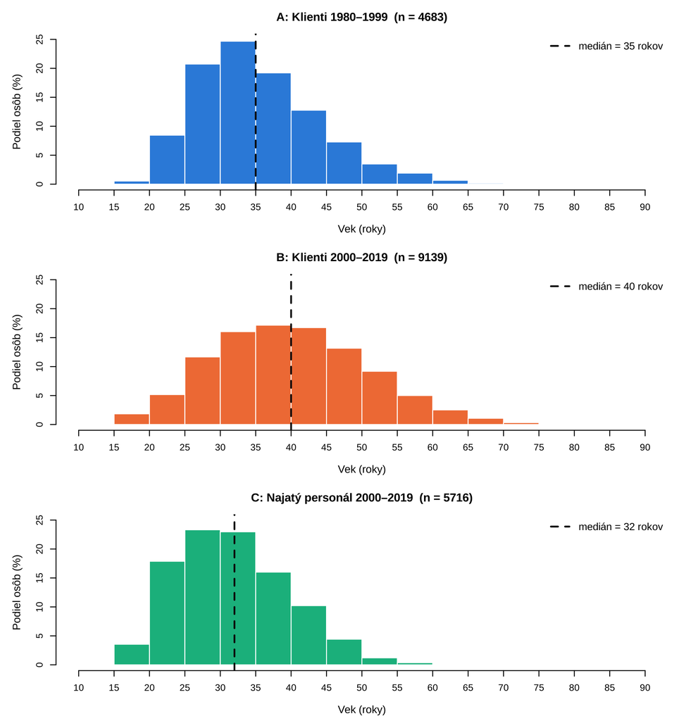

```r
farby <- c("#2a78d6", "#eb6834", "#1baf7a")   # modrá, oranžová, tyrkysová
hranice <- seq(10, 90, by = 5)                # 5-ročné vekové intervaly
vek_podla_skupiny <- split(podskupiny$age, podskupiny$skupina)

# percentá v intervaloch pre každú skupinu (kvôli spoločnej osi y)
percenta <- lapply(vek_podla_skupiny, function(x)
  100 * hist(x, breaks = hranice, plot = FALSE)$counts / length(x))
y_max <- ceiling(max(unlist(percenta)) / 5) * 5

par(mfrow = c(3, 1), mar = c(4.5, 5, 3, 1), cex.main = 1.25, cex.lab = 1.15)
for (i in 1:3) {
  x <- vek_podla_skupiny[[i]]
  h <- hist(x, breaks = hranice, plot = FALSE)
  h$counts <- percenta[[i]]                   # namiesto počtov vykreslíme percentá
  plot(h, col = farby[i], border = "white", ylim = c(0, y_max), xaxt = "n",
       main = paste0(nazvy[i], "  (n = ", length(x), ")"),
       xlab = "Vek (roky)", ylab = "Podiel osôb (%)")
  axis(1, at = hranice)
  abline(v = median(x), lty = 2, lwd = 2, col = "#0b0b0b")
  legend("topright", legend = paste("medián =", median(x), "rokov"),
         lty = 2, lwd = 2, bty = "n", cex = 1.1)
}
```

**Interpretácia histogramu**

Histogram ukazuje rozdelenie veku (koľko percent ľudí z podskupiny spadá do jednotlivých 5-ročných intervalov). Všetky tri rozdelenia sú jednovrcholové a mierne **pravostranne zošikmené** – väčšina ľudí je v strednom veku a „chvost“ smeruje k vyšším vekom, pretože veľmi mladí ľudia na Everest takmer nechodia, ale starší áno.

- **A: Klienti 1980–1999** – najviac ľudí je vo veku 25–40 rokov, medián je 35 rokov. Ľudia nad 50 rokov tvoria len 7,5 %. Ide o obdobie, keď na Everest chodili najmä športoví horolezci.
- **B: Klienti 2000–2019** – celé rozdelenie je **posunuté doprava** (medián 40 rokov, o 5 rokov viac než v skupine A) a je **širšie a plochejšie**: podstatná časť klientov je rozložená v širokom rozpätí od 20 až po 65 rokov. Podiel ľudí nad 50 rokov stúpol na 20,7 %, teda takmer každý piaty klient. Objavujú sa aj extrémne hodnoty – najstarší člen mal 85 rokov. To zodpovedá komerčným expedíciám, na ktoré si môže zaplatiť aj starší, finančne zabezpečený človek bez dlhej horolezeckej kariéry.
- **C: Najatý personál 2000–2019** – rozdelenie je **najviac posunuté doľava a najužšie**: medián je iba 32 rokov, 39,7 % personálu má menej ako 30 rokov a nad 50 rokov je len 2,1 %. Práca vysokohorského nosiča je fyzicky extrémne náročná, preto ju vykonávajú hlavne mladí muži.

Najväčší rozdiel je teda medzi klientmi a personálom v rovnakom období (B vs. C): klienti sú v priemere o 8,2 roka starší ako šerpovia, ktorí ich na vrchol sprevádzajú.

# 4 Krabicový graf (boxplot)

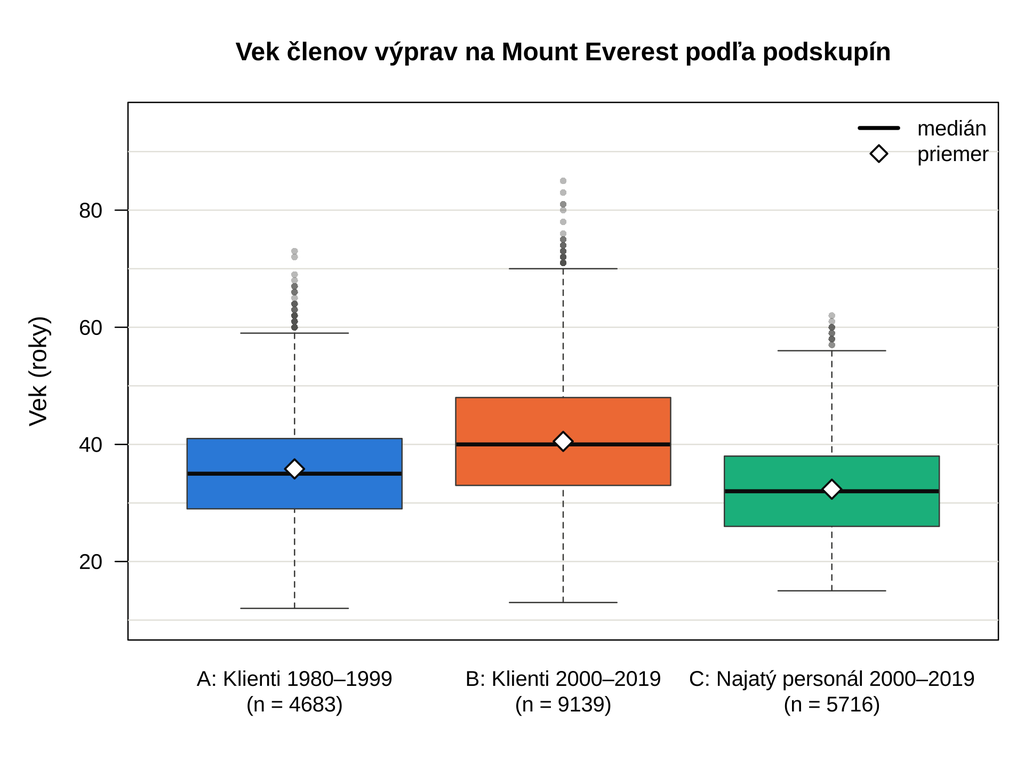

```r
pocty <- table(podskupiny$skupina)
priemery <- tapply(podskupiny$age, podskupiny$skupina, mean)
popisky <- paste0(c("A: Klienti 1980–1999", "B: Klienti 2000–2019",
                    "C: Najatý personál 2000–2019"), "\n(n = ", pocty, ")")

par(mar = c(5, 5, 4, 1), cex.lab = 1.15)
# prázdny graf s vodorovnou mriežkou, krabice nakreslíme až na ňu
plot(NA, xlim = c(0.5, 3.5), ylim = c(10, 95), xaxt = "n", las = 1,
     main = "Vek členov výprav na Mount Everest podľa podskupín",
     xlab = "", ylab = "Vek (roky)")
abline(h = seq(10, 90, by = 10), col = "#e1e0d9")
boxplot(age ~ skupina, data = podskupiny, add = TRUE, at = 1:3, axes = FALSE,
        col = farby, border = "#3a3a38", medcol = "#0b0b0b", medlwd = 3,
        pch = 16, outcol = adjustcolor("#52514e", alpha.f = 0.4), cex = 0.7)
points(1:3, priemery, pch = 23, bg = "white", col = "#0b0b0b", cex = 1.6, lwd = 1.5)
mtext(popisky, side = 1, at = 1:3, line = 1.2, padj = 0.5)
legend("topright", legend = c("medián", "priemer"),
       lty = c(1, NA), lwd = c(3, 1.5), pch = c(NA, 23), pt.bg = "white",
       pt.cex = 1.4, bty = "n")
```

**Interpretácia krabicového grafu**

Krabicový graf zobrazuje pre každú podskupinu medián (hrubá čierna čiara), dolný a horný kvartil Q1 a Q3 (okraje krabice – v krabici je stredných 50 % ľudí), fúzy (rozsah hodnôt do vzdialenosti 1,5 × IQR od krabice) a odľahlé hodnoty (body). Kosoštvorec označuje priemer.

- **Poloha (úroveň veku):** Krabica skupiny B leží najvyššie – medián 40 rokov, priemer 40,5 roka. Skupina A je nižšie (medián 35, priemer 35,8) a skupina C najnižšie (medián 32, priemer 32,3). Krabice B a C sa prekrývajú len čiastočne (v rozmedzí 33–38 rokov): horný kvartil personálu (38 rokov) je nižší ako medián klientov po roku 2000 (40 rokov), takže aspoň polovica klientov je staršia ako tri štvrtiny personálu.
- **Variabilita:** Skupina B má najvyššiu krabicu aj najdlhšie fúzy – medzikvartilové rozpätie IQR = 15 rokov (Q1 = 33, Q3 = 48) a smerodajnú odchýlku 10,8 roka. Skupiny A a C sú homogénnejšie (IQR = 12 rokov v oboch, smerodajná odchýlka 8,6 a 7,8). Klienti v komerčnej ére sú teda veľmi rôznorodí – od tínedžerov po dôchodcov.
- **Šikmosť a odľahlé hodnoty:** Vo všetkých skupinách je priemer o niečo vyššie ako medián a horný fúz je dlhší ako dolný, čo potvrdzuje pravostrannú šikmosť z histogramu. Odľahlé hodnoty sa vyskytujú iba smerom k vyššiemu veku: v skupine A ide o ľudí od 60 rokov, v skupine C o personál od 57 rokov. V skupine B sú vďaka veľkej variabilite za odľahlé považovaní až ľudia od 71 do 85 rokov.

# 5 Záver

Filtrovanie dát z Himalájskej databázy ukázalo zreteľné rozdiely medzi podskupinami ľudí na Mount Evereste:

1. **Klienti po roku 2000 sú starší** (medián 40 vs. 35 rokov) a **vekovo rôznorodejší** ako horolezci v rokoch 1980–1999 – na Everest dnes chodí oveľa viac ľudí v strednom a vyššom veku.
2. **Najatý personál (šerpovia) je najmladší a vekovo najhomogénnejší** (medián 32 rokov), keďže ide o fyzicky najnáročnejšiu prácu.
3. Zároveň výrazne stúpla úspešnosť výstupov klientov – z 15 % na 46,5 % (personál 78,1 %), čo tiež súvisí s komerčnými expedíciami, fixnými lanami a podporou šerpov.

Oba grafy teda podporujú rovnaký záver: komercializácia Everestu zmenila to, *kto* naň lezie – vrchol prestal byť doménou mladých športových horolezcov.